# 7 Love Songs

Damilare Olaleye

```r
library(stringr)
```

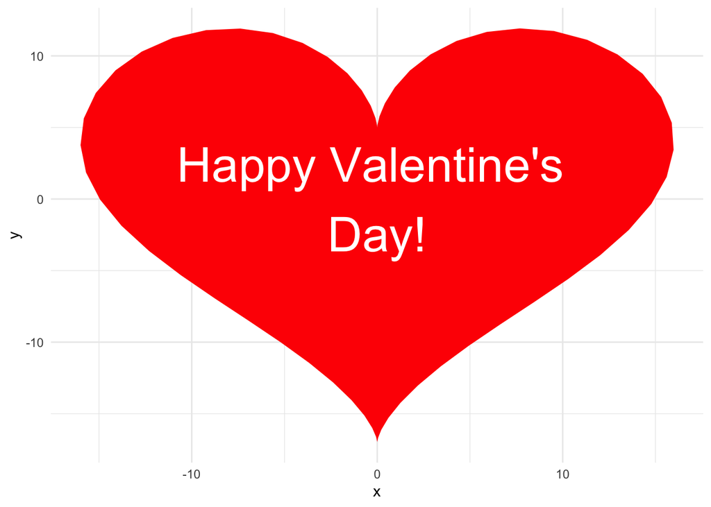

```r
require(ggplot2)
dat<- data.frame(t=seq(0, 2*pi, by=0.1) )
 xhrt <- function(t) 16*sin(t)^3
 yhrt <- function(t) 13*cos(t)-5*cos(2*t)-2*cos(3*t)-cos(4*t)
 dat$y=yhrt(dat$t)
 dat$x=xhrt(dat$t)
ggplot(dat, aes(x, y)) + theme_minimal() +
geom_polygon(fill = "red") +
annotate(geom = "text",x = 0, y = 0,
label = "Happy Valentine's \nDay!",
size = 12, color = "white")
```

1. Find the lyrics to two of your favorite love songs. Store the lyrics to the two songs in separate text files in your current working folder.

```r
song_one <- read.delim("loveSongs1.txt")
song_one
```

```
##                                             X..rtf1.ansi.ansicpg1252.cocoartf2511
## 1  \\cocoatextscaling0\\cocoaplatform0{\\fonttbl\\f0\\fswiss\\fcharset0 ArialMT;}
## 2              {\\colortbl;\\red255\\green255\\blue255;\\red26\\green26\\blue26;}
## 3                      {\\*\\expandedcolortbl;;\\cssrgb\\c13333\\c13333\\c13333;}
## 4                        \\margl1440\\margr1440\\vieww10800\\viewh8400\\viewkind0
## 5                                                                     \\deftab720
## 6                                         \\pard\\pardeftab720\\partightenfactor0
## 7                                   \\f0\\fs28 \\cf2 \\expnd0\\expndtw0\\kerning0
## 8                                  Closed off from love, I didn't need the pain\\
## 9                              Once or twice was enough, but it was all in vain\\
## 10                       Time starts to pass, before you know it, you're frozen\\
## 11                     But something happened, for the very first time with you\\
## 12                         My heart melts into the ground, found something true\\
## 13                       And everyone's looking round, thinking I'm going crazy\\
## 14                                               But I don't care what they say\\
## 15                                                         I'm in love with you\\
## 16                      They try to pull me away, but they don't know the truth\\
## 17                      My heart's crippled by the vein, that I keep on closing\\
## 18                                                        You cut me open and I\\
## 19                                      Keep bleeding, keep, keep bleeding love\\
## 20                                  I keep bleeding, I keep, keep bleeding love\\
## 21                                      Keep bleeding, keep, keep bleeding love\\
## 22                                                              You cut me open\\
## 23                               Trying hard not to hear, but they talk so loud\\
## 24                Their piercing sounds fill my ears, try to fill me with doubt\\
## 25                                                         Yet I know that\\'85\\
## 26                                                                              }
```

```r
song_two <- read.delim("loveSongs2.txt")
song_two
```

```
##                                             X..rtf1.ansi.ansicpg1252.cocoartf2511
## 1  \\cocoatextscaling0\\cocoaplatform0{\\fonttbl\\f0\\fswiss\\fcharset0 ArialMT;}
## 2              {\\colortbl;\\red255\\green255\\blue255;\\red26\\green26\\blue26;}
## 3                      {\\*\\expandedcolortbl;;\\cssrgb\\c13333\\c13333\\c13333;}
## 4                        \\margl1440\\margr1440\\vieww10800\\viewh8400\\viewkind0
## 5                                                                     \\deftab720
## 6                                         \\pard\\pardeftab720\\partightenfactor0
## 7                                   \\f0\\fs28 \\cf2 \\expnd0\\expndtw0\\kerning0
## 8                                                      When a man loves a woman\\
## 9                                           Can't keep his mind on nothing else\\
## 10                                                        He'll trade the world\\
## 11                                                For the good thing he's found\\
## 12                                                 If she's bad he can't see it\\
## 13                                                          She can do no wrong\\
## 14                                             Turn his back on his best friend\\
## 15                                                           If he put her down\\
## 16                                                     When a man loves a woman\\
## 17                                                     Spend his very last dime\\
## 18                                           Trying to hold on to what he needs\\
## 19                                                 He'd give up all his comfort\\
## 20                                                        Sleep out in the rain\\
## 21                                    If she said that's the way it ought to be\\
## 22                                                 Well, this man loves a woman\\
## 23                                                  I gave you everything I had\\
## 24                                      Trying to hold on to your precious love\\
## 25                                              Baby, please don't treat me bad\\
## 26                                                     When a man loves a woman\\
## 27                                                        Down deep in his soul\\
## 28                                                She can bring him such misery\\
## 29                                                         If she plays him\\'85}
```

2. Use the findwords( ) function to find the locations of all of the words in your first love song – store these locations in the variable song1.

```r
findwords <- function(loveSong1) {
  txt <- scan(loveSong1, "")
  txt <- tolower(gsub('[[:punct:]]+','', txt))
    wl <- list()
    for (i in 1:length(txt)) {
      wrd <- txt[i]
      wl[[wrd]] <- c(wl[[wrd]], i)
    }
    return(wl)
}

findwords("loveSongs1.txt") -> song1
head(song1)
```

```
## $rtf1ansiansicpg1252cocoartf2511
## [1] 1
##
## $cocoatextscaling0cocoaplatform0fonttblf0fswissfcharset0
## [1] 2
##
## $arialmt
## [1] 3
##
## $colortblred255green255blue255red26green26blue26
## [1] 4
##
## $expandedcolortblcssrgbc13333c13333c13333
## [1] 5
##
## $margl1440margr1440vieww10800viewh8400viewkind0
## [1] 6
```

3. Find the locations of the word “love” in your song.

```r
song1$love
```

```
## [1]  15  78 115 123 129
```

4. By use of the lapply function, find the number of times each word is used in your song.

```r
lapply(song1, length)
```

```
## $rtf1ansiansicpg1252cocoartf2511
## [1] 1
##
## $cocoatextscaling0cocoaplatform0fonttblf0fswissfcharset0
## [1] 1
##
## $arialmt
## [1] 1
##
## $colortblred255green255blue255red26green26blue26
## [1] 1
##
## $expandedcolortblcssrgbc13333c13333c13333
## [1] 1
##
## $margl1440margr1440vieww10800viewh8400viewkind0
## [1] 1
##
## $deftab720
## [1] 1
##
## $pardpardeftab720partightenfactor0
## [1] 1
##
## $f0fs28
## [1] 1
##
## $cf2
## [1] 1
##
## $expnd0expndtw0kerning0
## [1] 1
##
## $closed
## [1] 1
##
## $off
## [1] 1
##
## $from
```

[output cut: 235 more lines]

```
##
## $ears
## [1] 1
##
## $doubt
## [1] 1
##
## $yet
## [1] 1
##
## $that85
## [1] 1
##
## [[97]]
## [1] 1
```

5. By use of the lapply function, find the location of the first time each word is used in your song.

```r
lapply(song1, function(elem) elem[1])
```

```
## $rtf1ansiansicpg1252cocoartf2511
## [1] 1
##
## $cocoatextscaling0cocoaplatform0fonttblf0fswissfcharset0
## [1] 2
##
## $arialmt
## [1] 3
##
## $colortblred255green255blue255red26green26blue26
## [1] 4
##
## $expandedcolortblcssrgbc13333c13333c13333
## [1] 5
##
## $margl1440margr1440vieww10800viewh8400viewkind0
## [1] 6
##
## $deftab720
## [1] 7
##
## $pardpardeftab720partightenfactor0
## [1] 8
##
## $f0fs28
## [1] 9
##
## $cf2
## [1] 10
##
## $expnd0expndtw0kerning0
## [1] 11
##
## $closed
## [1] 12
##
## $off
## [1] 13
##
## $from
```

[output cut: 235 more lines]

```
##
## $ears
## [1] 149
##
## $doubt
## [1] 155
##
## $yet
## [1] 156
##
## $that85
## [1] 159
##
## [[97]]
## [1] 160
```

6. By use of the function alphawl(), sort your list alphanumerically. Demonstrate that it works.

```r
alphawl <- function(wrdlst){
 nms <- names(wrdlst)
 sn <- sort(nms)
 return(wrdlst[sn])
}

alphawl(song1)
```

```
## $<NA>
## NULL
##
## $all
## [1] 29
##
## $and
## [1]  61 108
##
## $arialmt
## [1] 3
##
## $away
## [1] 86
##
## $before
## [1] 36
##
## $bleeding
## [1] 111 114 118 122 125 128
##
## $but
## [1]  26  42  69  87 139
##
## $by
## [1] 96
##
## $care
## [1] 72
##
## $cf2
## [1] 10
##
## $closed
## [1] 12
##
## $closing
## [1] 103
##
## $cocoatextscaling0cocoaplatform0fonttblf0fswissfcharset0
```

[output cut: 235 more lines]

```
##
## $what
## [1] 73
##
## $with
## [1]  50  79 154
##
## $yet
## [1] 156
##
## $you
## [1]  37  51  80 104 130
##
## $youre
## [1] 40
```

7. By use of the function freqwl(), sort your list by the word frequency. Demonstrate that is works.

```r
freqwl <- function(wrdlst){
  freqs <- sapply(wrdlst,length)
  return(wrdlst[order(freqs)])
}

freqwl(song1)
```

```
## $rtf1ansiansicpg1252cocoartf2511
## [1] 1
##
## $cocoatextscaling0cocoaplatform0fonttblf0fswissfcharset0
## [1] 2
##
## $arialmt
## [1] 3
##
## $colortblred255green255blue255red26green26blue26
## [1] 4
##
## $expandedcolortblcssrgbc13333c13333c13333
## [1] 5
##
## $margl1440margr1440vieww10800viewh8400viewkind0
## [1] 6
##
## $deftab720
## [1] 7
##
## $pardpardeftab720partightenfactor0
## [1] 8
##
## $f0fs28
## [1] 9
##
## $cf2
## [1] 10
##
## $expnd0expndtw0kerning0
## [1] 11
##
## $closed
## [1] 12
##
## $off
## [1] 13
##
## $from
```

[output cut: 235 more lines]

```
##
## $but
## [1]  26  42  69  87 139
##
## $you
## [1]  37  51  80 104 130
##
## $bleeding
## [1] 111 114 118 122 125 128
##
## $i
## [1]  16  70 100 109 116 119 157
##
## $keep
##  [1] 101 110 112 113 117 120 121 124 126 127
```

8. Repeat questions 2 and 3 for your second song. Compare the love in your two songs.

```r
# question 2

findwords <- function(loveSong2) {
  txt <- scan(loveSong2, "")
  txt <- tolower(gsub('[[:punct:]]+','', txt))
    wl <- list()
    for (i in 1:length(txt)) {
      wrd <- txt[i]
      wl[[wrd]] <- c(wl[[wrd]], i)
    }
    return(wl)
}

findwords("loveSongs2.txt") -> song2
head(song2)
```

```
## $rtf1ansiansicpg1252cocoartf2511
## [1] 1
##
## $cocoatextscaling0cocoaplatform0fonttblf0fswissfcharset0
## [1] 2
##
## $arialmt
## [1] 3
##
## $colortblred255green255blue255red26green26blue26
## [1] 4
##
## $expandedcolortblcssrgbc13333c13333c13333
## [1] 5
##
## $margl1440margr1440vieww10800viewh8400viewkind0
## [1] 6
```

question 3

```r
song2$love
```

```
## [1] 118
```